# StockResearch

Gabriel Foix

2021-02-26

Buy Quality at the a good momentum and get rid of the fishy stocks on time. That's all.

### Define candidates

Download all info needed applying the following filters:

### Factor 1: Quality

1. Healthy debts: A company shoud generate cash in order to repay its debt. The **Free Cash Flow to Debt** ratio is a good indicator of how quick a company pays back its debt. The lower this ratio the better.

FCF2D = $\frac{Debt}{Free Cash Flow}$

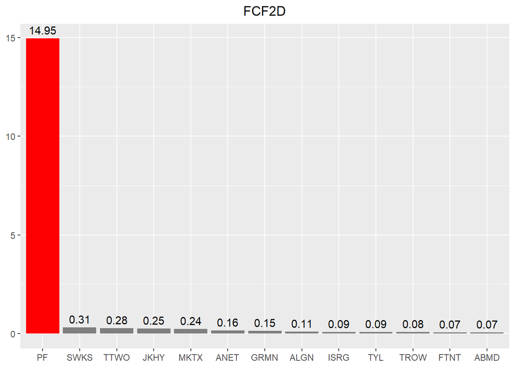

2. Profitability: ROA

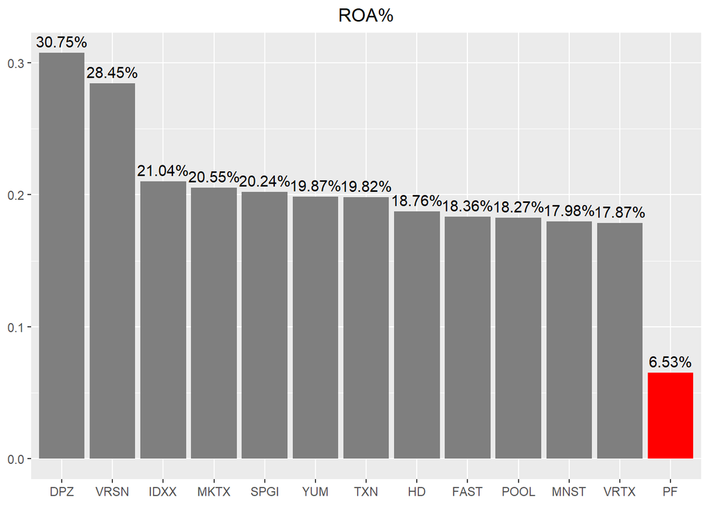

3. High Margin: We look for companies that generate free cash flow compare to its price. The **Free Cash Flow to Entreprise Value** ratio tells us how many years of cash flow would be needed to the return the 100% of the investment. Again, the lower, the better. Values bellow 1 would mean "free lunch".

FCF2EV = $\frac{EV}{Free Cash Flow}$

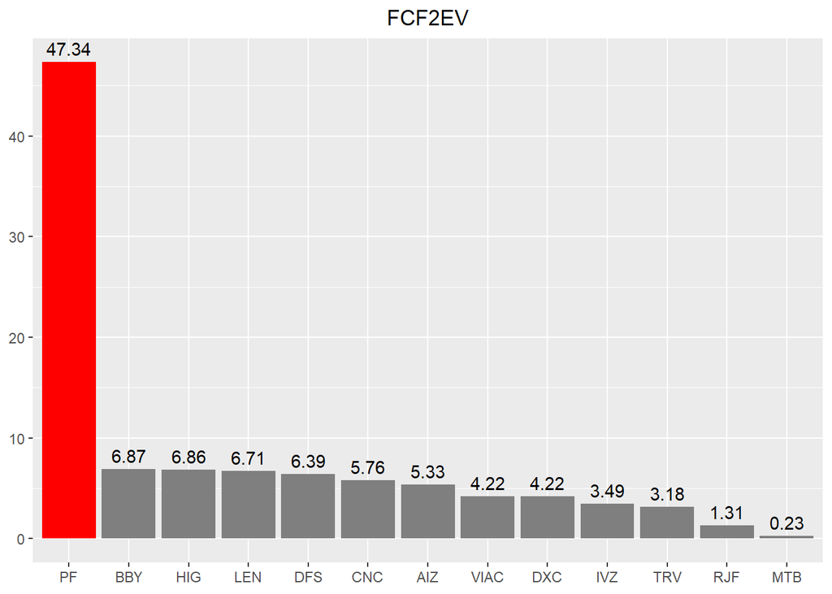

#### Download Historical Data

Download only stocks not filtered previously

### Value touch

Filter out stocks with PER > 40

Report Candidates

Filter Summary

| Filter | NStocks |
| --- | --- |
| Initial | 505 |
| ROA | 419 |
| FCF | 364 |
| Hist1Y | 361 |
| PER | 231 |

### Factor 2: Momentum

Don't hold onto a stock simply because it is high quality. So called quality stocks have cycles too. Stan Weinstein (page 177)

Generic Intermediate-Term Momentum Based on Gray-Vogel (page 80)

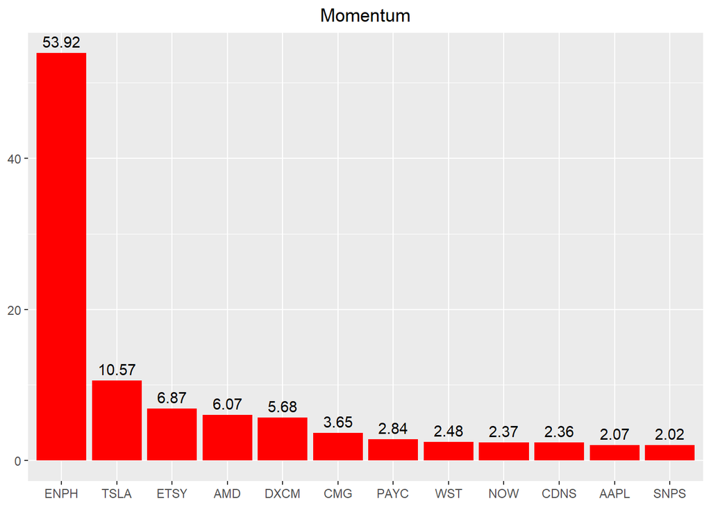

### Factor 3: Timing Signal

Sell Signal - Pr < 1% SMA 30 weeks and slope negative (< -0.2)  
Buy Signal - 109% * SMA30 < Pr > SMA 30 and slope positive (> 0.2)  
Hold Signal - Neither Buy nor Sell

#### Calc Market Cap

Using free float shares

### Summary

Summary

| Ticker | Signal | Quality | Momentum | Final_rank | PER | MCap |
| --- | --- | --- | --- | --- | --- | --- |
| AAPL | HOLD | 368.0 | 351 | 397.0 | 32.888528 | 2.033648e+12 |
| HOLX | HOLD | 402.5 | 309 | 396.0 | 13.692307 | 1.845522e+10 |
| TGT | HOLD | 370.0 | 338 | 395.0 | 24.332140 | 9.158165e+10 |
| COST | HOLD | 390.0 | 304 | 390.5 | 33.983573 | 1.461945e+11 |
| LOW | HOLD | 382.0 | 305 | 388.0 | 20.612903 | 1.166628e+11 |
| TER | HOLD | 339.0 | 335 | 386.0 | 30.049066 | 2.136337e+10 |
| GRMN | HOLD | 355.0 | 316 | 384.0 | 23.988394 | 1.768382e+10 |
| FAST | HOLD | 381.0 | 286 | 382.0 | 31.120805 | 2.653149e+10 |
| KLAC | HOLD | 326.5 | 339 | 380.5 | 35.597622 | 4.785148e+10 |
| TSCO | HOLD | 336.5 | 329 | 380.5 | 24.915362 | 1.839731e+10 |
| QCOM | BUY | 318.0 | 340 | 378.0 | 23.280342 | 1.544488e+11 |
| CDNS | HOLD | 302.0 | 352 | 377.0 | 36.580243 | 3.878177e+10 |
| SPGI | HOLD | 391.0 | 259 | 375.0 | 34.095237 | 7.915407e+10 |
| BBY | HOLD | 409.0 | 240 | 374.0 | 14.671052 | 2.328090e+10 |
| PWR | HOLD | 336.5 | 311 | 373.0 | 31.032568 | 1.150376e+10 |
| CLX | SELL | 375.0 | 269 | 371.0 | 18.944230 | 2.269116e+10 |
| PG | HOLD | 361.0 | 279 | 370.0 | 23.342781 | 3.038611e+11 |
| ORLY | HOLD | 371.0 | 268 | 369.0 | 19.011049 | 3.129723e+10 |
| POOL | HOLD | 287.0 | 341 | 367.0 | 37.321069 | 1.302385e+10 |
| ACN | BUY | 400.0 | 226 | 365.0 | 30.883800 | 1.588721e+11 |
| PHM | HOLD | 386.0 | 236 | 363.0 | 8.715224 | 1.167676e+10 |
| TROW | HOLD | 411.0 | 210 | 362.0 | 16.246493 | 3.655078e+10 |
| AMAT | HOLD | 345.0 | 273 | 361.0 | 28.268357 | 1.076291e+11 |
| PKI | HOLD | 310.5 | 303 | 359.0 | 19.416384 | 1.275577e+10 |
| HD | HOLD | 384.0 | 228 | 356.0 | 21.636516 | 2.770743e+11 |
| NEM | SELL | 359.0 | 253 | 356.0 | 15.484055 | 4.337616e+10 |
| CPRT | HOLD | 278.0 | 330 | 353.0 | 36.990852 | 2.303950e+10 |
| MSFT | HOLD | 269.0 | 337 | 351.5 | 34.647384 | 1.726791e+12 |
| TXN | HOLD | 353.0 | 249 | 348.0 | 28.865617 | 1.582474e+11 |
| LEN | BUY | 389.0 | 207 | 343.0 | 10.574815 | 2.372916e+10 |

[output cut: 201 more lines]

Save output in template